# R Notebook

## 1.1 File metadata

Template author: Morgan Carr-Markell  
Template last modified on: April 4, 2023  
Notebook modified by: Katie Wang  
Notebook last modified on: April 11, 2023

## 1.2 Data sources

1. Fill in your data sources:
- Species occurrence data:

GBIF.org (03 April 2023) GBIF Occurrence Download https://doi.org/10.15468/dl.nepwjz

- Environmental data:

Tyberghein L, Verbruggen H, Pauly K, Troupin C, Mineur F, De Clerck O (2012) Bio-ORACLE: A global environmental dataset for marine species distribution modelling. Global Ecology and Biogeography, 21, 272–281.

Assis, J., Tyberghein, L., Bosh, S., Verbruggen, H., Serrão, E. A., & De Clerck, O. (2017). Bio-ORACLE v2.0: Extending marine data layers for bioclimatic modelling. Global Ecology and Biogeography.

## 1.3 Code sources

Much of the code is inspired by or directly adapted from these four sources:

The ENMeval 2.0 Vignette By Jamie M. Kass, Robert Muscarella, Gonzalo E. Pinilla-Buitrago, and Peter J. Galante Date: January 9th, 2023 https://jamiemkass.github.io/ENMeval/articles/ENMeval-2.0-vignette.html

Preparing Data for MaxEnt Species Distribution Modeling Using R By Dale Watt Date: October 9th, 2018 https://www.azavea.com/blog/2018/10/09/preparing-data-for-maxent-species-distribution-modeling-using-r/

Tutorials from The Banta Lab By Josh Banta https://sites.google.com/site/thebantalab/tutorials?authuser=0

Code shared by Prof. Stephen Adolph and his students Daniel Furman and Sarah Halvorsen from their desert night lizard species distribution modeling project https://magazine.hmc.edu/summer-2019/researching-for-an-answer/

## 1.4 Libraries

```r
library(tidyverse)    # wrangle data
library(sf)           # vector data
library(dismo)        # species distribution modeling
library(rgdal)        # projections and geospatial functions
library(raster)       # raster data
library(rJava)        # R to Java interface
library(maptools)     # helps with manipulating geographic data
library(sp)           # classes for manipulating spatial data
library(rgeos)        # interface to geometry engine
library(randomForest) # classification and regression random forest models
library(ipred)        # improved prediction using techniques such as bagging
library(ENMeval)      # MaxEnt modeling
```

## 1.5 Read in data

### 1.5.1 Responses (points):

2. Read in your point data (csv files):

```r
setwd('..') # move up a directory; I'm using the processed data files I exported during HW7
occurrence <- read.csv("hw7-kcw27/processed_data/CS_occurrences.csv")

background <- read.csv("hw7-kcw27/processed_data/background.csv")
```

### 1.5.2 Environmental predictor variables (rasters):

3. Read in your environmental layers and make a raster stack:

```r
setwd('..') # move up a directory; I'm using the processed data files I exported during HW7
# I think that when these files were exported from HW7, the .tif file extension replaced whatever came after the
# last period in the file name

# I'll make two raster stacks: one for the present climate and one for the future climate

# Get raster file list
predictor_list_present <- c("hw7-kcw27/processed_data/Present.Benthic.Max.Depth.Temperature.Lt.tif",
                    "hw7-kcw27/processed_data/Present.Benthic.Max.Depth.Salinity.Lt.tif")
predictor_list_future <- c("hw7-kcw27/processed_data/X2050AOGCM.RCP85.Benthic.Max.Depth.Temperature.Lt.min.tif.tif",
                           "hw7-kcw27/processed_data/X2050AOGCM.RCP85.Benthic.Max.Depth.Salinity.Lt.min.tif.tif")

# Make raster stack from files
predictors_present <- stack(predictor_list_present)
predictors_future <- stack(predictor_list_future)

predictors_present
```

```
class      : RasterStack
dimensions : 1260, 1733, 2183580, 2  (nrow, ncol, ncell, nlayers)
resolution : 0.08333333, 0.08333333  (x, y)
extent     : -103.6667, 40.75, -41.33333, 63.66667  (xmin, xmax, ymin, ymax)
crs        : +proj=longlat +datum=WGS84 +no_defs
names      :   layer.1,   layer.2
min values : -1.890870,  4.969467
max values :  28.55638,  40.56975
```

```r
predictors_future
```

```
class      : RasterStack
dimensions : 1260, 1733, 2183580, 2  (nrow, ncol, ncell, nlayers)
resolution : 0.08333333, 0.08333333  (x, y)
extent     : -103.6667, 40.75, -41.33333, 63.66667  (xmin, xmax, ymin, ymax)
crs        : +proj=longlat +datum=WGS84 +no_defs
names      :   layer.1,   layer.2
min values : -1.940000,  4.972535
max values :  29.70599,  40.56604
```

## 1.6 Processing data

### 1.6.1 Renaming layers in stack

4. Look at the raster file names and then rename the raster stack layers accordingly:

```r
# the names were "layer.1" and "layer.2" so I need to rename them
# to confirm the ordering of the raster layers:
predictor_list_present
```

```
[1] "hw7-kcw27/processed_data/Present.Benthic.Max.Depth.Temperature.Lt.tif"
[2] "hw7-kcw27/processed_data/Present.Benthic.Max.Depth.Salinity.Lt.tif"
```

```r
predictor_list_future
```

```
[1] "hw7-kcw27/processed_data/X2050AOGCM.RCP85.Benthic.Max.Depth.Temperature.Lt.min.tif.tif"
[2] "hw7-kcw27/processed_data/X2050AOGCM.RCP85.Benthic.Max.Depth.Salinity.Lt.min.tif.tif"
```

```r
# The names of the variables need to be the same so that the model recognizes them
# Or maybe it goes off the order of variables, since when the predictors had different
# names, it didn't give me an error
names(predictors_present) <- c("Temperature", "Salinity")
names(predictors_future) <- c("Temperature", "Salinity")

# check that the raster layers have been renamed
predictors_present
```

```
class      : RasterStack
dimensions : 1260, 1733, 2183580, 2  (nrow, ncol, ncell, nlayers)
resolution : 0.08333333, 0.08333333  (x, y)
extent     : -103.6667, 40.75, -41.33333, 63.66667  (xmin, xmax, ymin, ymax)
crs        : +proj=longlat +datum=WGS84 +no_defs
names      : Temperature,  Salinity
min values :   -1.890870,  4.969467
max values :    28.55638,  40.56975
```

```r
predictors_future
```

```
class      : RasterStack
dimensions : 1260, 1733, 2183580, 2  (nrow, ncol, ncell, nlayers)
resolution : 0.08333333, 0.08333333  (x, y)
extent     : -103.6667, 40.75, -41.33333, 63.66667  (xmin, xmax, ymin, ymax)
crs        : +proj=longlat +datum=WGS84 +no_defs
names      : Temperature,  Salinity
min values :   -1.940000,  4.972535
max values :    29.70599,  40.56604
```

### 1.6.2 Categorical variables

5. If any of your raster layers are categorical, convert them to factors (so they aren’t treated as numbers):

```r
# none are categorical
```

### 1.6.3 Extracting environmental variables for each point

6. Use raster::extract() to extract the raster values for your occurrence points and background points:

```r
presence_values_present <- raster::extract(predictors_present, occurrence)
background_values_present <- raster::extract(predictors_present, background)

presence_values_future <- raster::extract(predictors_future, occurrence)
background_values_future <- raster::extract(predictors_future, background)
```

7. What are the dimensions of these 2 matrices?  
   The presence values matrices have 2036 rows and 2 columns. The background values matrices have 10000 rows and 2 columns. These matrices are made in order to demonstrate how the raster::extract() function works, since it’s used later on.

### 1.6.4 Dividing the points into training and testing sets

8. Process presence points into a training set to train the model and a held-out test set to assess how well the model predicts areas with high and low suitability for this species.

```r
set.seed(100) # decided this seed using random number generator

group <- sample(x = c(1, 2, 3, 4, 5), # we want to assign group numbers
                size = nrow(occurrence), # to each row (observation)
                replace = T) # this means it will keep randomly drawing 1-5

presence_train <- occurrence[group != 1, ] # make a training set of ~80 percent
presence_test <- occurrence[group == 1, ] # make a testing set of ~20 percent
```

9. Process background points in the same way.

```r
set.seed(100) # decided this seed using random number generator

group <- sample(x = c(1, 2, 3, 4, 5),
                size = nrow(background),
                replace = T)

background_train <- background[group != 1, ] #make a train set of ~80 percent
background_test <- background[group == 1, ] #make a test set of ~20 percent
```

10. Process combined presence and background training points to extract the values for all predictor variables.

```r
set.seed(100) # decided this seed using random number generator

# combine training points
train <- rbind(presence_train, background_train)

# col of ones and zeros representing presence or background
pb_train <- c(rep(1, nrow(presence_train)), rep(0, nrow(background_train)))

# extract raster values for training background and presence
environ_train_present <- raster::extract(predictors_present, train)

# add presence/background column
environ_train_present <- cbind(presence_background = pb_train, environ_train_present) %>%
  data.frame() # make into a data frame

presence_test_present <- raster::extract(predictors_present, presence_test) %>%
  data.frame()

background_test_present <- raster::extract(predictors_present, background_test) %>%
  data.frame()

# remove any NAs
presence_test_present <- presence_test_present[complete.cases(presence_test_present),]

background_test_present <- background_test_present[complete.cases(background_test_present),]

environ_train_present <- environ_train_present[complete.cases(environ_train_present),]

# edit: deleted all the _future versions of the three because for the future we only need the raster climate layer
```

11. Look at the first few rows of each data frame using the head() function to check your work:

```r
head(presence_test_present)
```

|  | Temperature | Salinity |
| --- | --- | --- |
| 3 | 15.51238 | 34.31907 |
| 4 | 16.24278 | 14.48869 |
| 5 | 11.07109 | 33.00991 |
| 8 | 13.68327 | 38.32164 |
| 10 | 16.10205 | 31.60957 |
| 12 | 14.79230 | 38.58930 |

```r
head(background_test_present)
```

|  | Temperature | Salinity |
| --- | --- | --- |
| 1 | 9.599627 | 35.17942 |
| 2 | 2.752471 | 34.93480 |
| 3 | 1.811014 | 34.88877 |
| 4 | 4.918886 | 32.84832 |
| 5 | 25.516781 | 36.01305 |
| 6 | 3.586399 | 34.98830 |

```r
head(environ_train_present)
```

|  | presence_background | Temperature | Salinity |
| --- | --- | --- | --- |
| 1 | 1 | 17.127426 | 38.98808 |
| 2 | 1 | 15.737335 | 34.33110 |
| 5 | 1 | 4.557518 | 32.13416 |
| 6 | 1 | 4.556131 | 33.11077 |
| 7 | 1 | 16.766560 | 33.65913 |
| 8 | 1 | 17.927101 | 35.46728 |

12. For the sake of time, decide whether you want to fit a model using the Random Forest algorithm or the MaxEnt algorithm. Either is fine. If you fit a MaxEnt model, you will need to provide tuning parameters and then select the model with the lowest AIC value.  
    I will fit a Random Forest model.

## 1.7 Fitting a model

13. Fit the model:

```r
# Saving the model to input into the randomForest() function
model_present <- presence_background ~  Temperature + Salinity

rf_model_present <- randomForest(model_present, # model specifies response variable and predictor variables
                         data = environ_train_present, # the data frame of training data
                         coob = TRUE) # calculates the "out of bag" error
rf_model_present
```

```
Call:
 randomForest(formula = model_present, data = environ_train_present,      coob = TRUE)
               Type of random forest: regression
                     Number of trees: 500
No. of variables tried at each split: 1

          Mean of squared residuals: 0.05026217
                    % Var explained: 57.77
```

```r
# edit: there shouldn't be a model for the future; deleted these lines
```

### 1.7.1 Assessing model performance with the test data

14. Make a data frame of model predictions using the held-out test data:

```r
# These lines fix an error in which R decided that the df was not in
# the right format for the predict function
presence_test_present <- rbind(environ_train_present[1, -1] , presence_test_present)
presence_test_present <- presence_test_present[-1, ]

# The base R predict function let's us use any model to make predictions from new data
predict_test_presence_present <- predict(object = rf_model_present,
                                 newdata = presence_test_present)

# Again, these lines fix an error in which R decided that the df was not in
# the right format for the predict function
background_test_present <- rbind(environ_train_present[1, -1] , background_test_present)
background_test_present <- background_test_present[-1, ]


predict_test_background_present <- predict(object = rf_model_present,
                                 newdata = background_test_present)

# Let's combine these predictions so we can plot them
predict_test_presence_present <- data.frame(prediction = predict_test_presence_present) %>%
  mutate(presence_background = 1)

predict_test_background_present <- data.frame(prediction = predict_test_background_present) %>%
  mutate(presence_background = 0)

rf_predictions_present <- rbind(predict_test_presence_present, predict_test_background_present)

# also deleted the future versions of variables here
```

15. Now make box plots comparing the predictions for presence test points and background test points. Remember to use factor(presence_background) rather than just presence_background or R will treat it as a number:

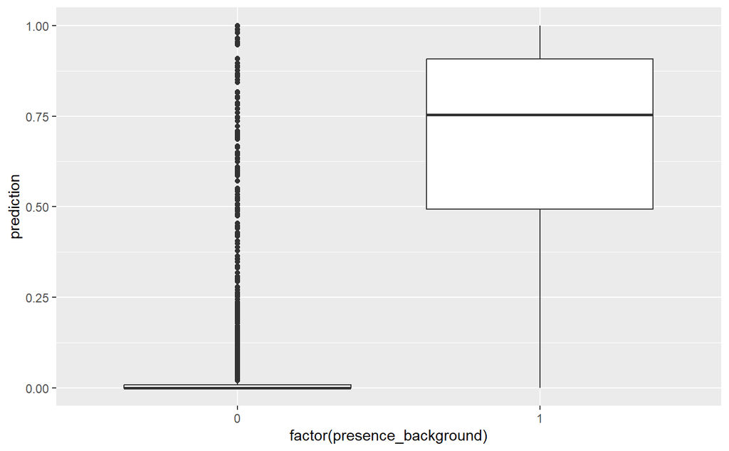

```r
rf_predictions_present %>%
  ggplot() +
  geom_boxplot(aes(x = factor(presence_background), y = prediction))
```

### 1.7.2 Plotting the predictions across the landscape

17. Use the raster::predict function to save predictions across the landscape:

```r
predictions_rf_model_present <- raster::predict(predictors_present,
                                                rf_model_present,
                                                ext = raster::extent(predictors_present))
# you can change ext to a set of coordinates to bound European waters

# for the future, use the model you trained on the present data
predictions_rf_model_future <- raster::predict(predictors_future, # same variable names as _present but different raster data
                                                rf_model_present,
                                                ext = raster::extent(predictors_future))
```

18. Plot that layer and also plot the occurrence and background points on top of it to assess whether it seems reasonable:

```r
if (!dir.exists("figures")){
  dir.create("figures")
}

# Set the location to save the plot
png(filename = 'figures/predictions_present.png',pointsize=5, width=2800, height=2000, res=800)
# Then make the plot
plot(predictions_rf_model_present, main = 'Random Forest predicted probabilities')
points(background, col = 'red', pch = 16, cex = 0.2)
points(occurrence, col = 'black', pch = 16, cex = 0.2)
```

```r
# a copy without points so it's easier to see the predicted probabilities
png(filename = 'figures/predictions_present_no_points.png',pointsize=5, width=2800, height=2000, res=800)
# Then make the plot
plot(predictions_rf_model_present, main = 'Random Forest predicted probabilities')
```

19. Look in the new figures folder at the plot you just made. How do the predicted probabilities compare to the actual occurrences?  
    It’s hard to see the predicted probabilities (the gradient from red to green) behind all the red and black points. I can see that the model predicted areas of high probability of observing crabs (the green areas) that don’t coincide entirely with the black points (the locations where crab occurrences were observed) so that suggests that the model isn’t overfit, which is good.

## 1.8 Plotting predictions in another landscape or with future climate projections

### 1.8.1 Read in raster layers and make stack

20. Read in the raster layers for the future climate scenario or other region:

```r
# done earlier
```

21. Create a raster stack (make sure that the crs, extent, and resolution match first) and rename the layers as you did above:

```r
# done earlier
```

### 1.8.2 Plotting model predictions

22. Use the raster::predict function to save the predictions for the new landscape/future climate:

```r
# done in Q17
```

23. Save a plot of those predictions to a file using the png function (no points to plot on top this time):

```r
png(filename = 'figures/predictions_future.png',pointsize=5, width=2800, height=2000, res=800)
# Then make the plot
plot(predictions_rf_model_future, main = 'Random Forest predicted probabilities')
```

## 1.9 Calculating area of regions above a suitability threshold

24. Calculate the suitable range above some threshold (you decide on the threshold based on the range of predictions) for both the current range and the range in the future or another region:

```r
# first determine what thresholds to use
evaluate(presence_test_present, background_test_present, rf_model_present)
```

```
class          : ModelEvaluation
n presences    : 324
n absences     : 1999
AUC            : 0.962685
cor            : 0.7610459
max TPR+TNR at : 0.130187
```

```r
# should use the same threshold for both the present and future models for consistency
(0.130187 + 0.1492) / 2
```

[output not shown]

```
[1] 0.1396935
```

```r
# Area calculation for present range

# save and then modify full raster
predictions_present <- predictions_rf_model_present
predictions_present[predictions_present <= 0.1396935] <- NA

# get sizes of all cells with suitability over threshold
cell_size <- area(predictions_present,
                  na.rm = TRUE,
                  weights = FALSE)

# delete any NAs from vector of all raster cells
cell_size <- cell_size[!is.na(cell_size)]

# compute area [km2] of all cells in prediction_over50
suitable_area_present <- length(cell_size)*mean(cell_size)

suitable_area_present
```

```
[1] 2646495
```

```r
# Area calculation for future range

# save and then modify full raster
predictions_future <- predictions_rf_model_future
predictions_future[predictions_future <= 0.1396935] <- NA

# get sizes of all cells with suitability over threshold
cell_size <- area(predictions_future,
                  na.rm = TRUE,
                  weights = FALSE)

# delete any NAs from vector of all raster cells
cell_size <- cell_size[!is.na(cell_size)]

# compute area [km2] of all cells in prediction_over50
suitable_area_future <- length(cell_size)*mean(cell_size)

suitable_area_future
```

```
[1] 3394913
```

It seems that the amount of suitable habitat for the crabs will increase quite a bit.